# FATLD in R

We first load the 82 $4^12^7$ 32-run designs of the catalog. To characterize them, we use the `Design` object from the `fatld` package. This package is loaded in `R` using the `reticulate` package. The only information needed to build the design are:

- the run size
- the number of four-level factors
- the column numbers

We extract these information for the data files of the catalog and format them into a list to be processed by the `purrr::map` function later.

```r
load('../data/N32_m1_n7_R3.rds')

design_info <- data |>
  select(columns) |>
  mutate(
    m = 1L,
    run_size = 32L,
    .before = "columns"
  ) |>
  split(1:nrow(data))
```

Now, we create a small function to extract the number of words of length 3 of type 0 and type 1 of each design. Then, we plot them on a scatter plot.

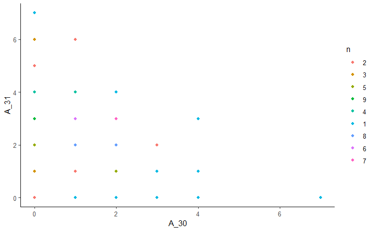

```r
#' Function to compute the A_3 value of a design
compute_A3 <- function(df){
  # Columns must be a list of integer
  cols <- as.integer(unlist(strsplit(df$columns, ",")))
  design <- fatld$Design(df$run_size, df$m, cols)
  # WLP values start on A_3
  design$twlp()[1] |> unlist()
}

A_3 <- purrr::map(design_info, compute_A3)
df <- as.data.frame(do.call(rbind, A_3))
colnames(df) <- c('A_30', 'A_31')

df |>
  group_by(A_30, A_31) |>
  summarise(n = as.factor(n()), .groups = "drop") |>
  ggplot(aes(A_30, A_31, color = n)) +
  geom_point() +
  theme_classic()
```

Now we can look more precisely at the designs with $A_3=0$ or $A_3=1$ and see if their WLP can differentiate them (up to $A_4$). If not, we can then look at the number of clear 2FI for each design. We could also try to look at the ALP and see what it says about the designs.